# Proper Orthogonal Decomposition based reduced order modeling for the heat equation

### Solve reduced order model

Now that all the groundwork has been laid, we will now actually solve the recuced order model. \ First, we specify the parameters of the time discretization:

```python
# start time
t = 0.
# end time
T = 0.5
# time step size
Δt = 0.01
# one-step theta
θ = 0.5
```

We now define the expression for the initial condition as $u_0$ and interpolate it in the function space $V$. Here we will use the variable $u_n$ as the solution from the last timestep. We need to briefly discuss how the reduced initial condition can be computed because in general it is not sufficient to simply restrict the initial condition from the FEM to the POD space, i.e. $$ \vec{u}_r^0 \neq \Psi^T \vec{u}_h^0. $$ Instead we need to include the weight matrix $W$ and it holds in general $$ \vec{u}_r^0 = \Psi^T W \vec{u}_h^0 $$ and for our particular case where we chose $W = M$, we thus get $$ \vec{u}_r^0 = \Psi^T M \vec{u}_h^0. $$ To understand why we need to use the weighting matrix when computing the reduced intial condition, we need to take into account that we get the initial condition through the projection $$ (u_r(0) - u_h(0), \psi_r^j) = 0 \quad \forall 1\leq i \leq r, $$ where $\psi_r^j$ is the $j$.th POD basis function which corresponds to the basis vector $\psi_j$ and $(\cdot, \cdot)$ stands for the inner product that we are using, e.g. in the case $W = M$ this is the $L^2(\Omega)$ inner product. It is left as an exercise to the reader that by expressing $u_r(0)$ and $u_h(0)$ as a linear combination of the POD or FEM basis, we arrive at the formula $$ \vec{u}_r^0 = \Psi^T W \vec{u}_h^0. $$

```python
# initial condition
u_0 = Expression('sin(pi*x[0])*sin(pi*x[1])', degree=2, pi=math.pi)

# u_n: solution from last time step
u_n = np.dot(np.dot(pod_basis.T, M.array()), np.array(interpolate(u_0, V).vector()))
```

Next, we create a matrix to store the reduced snapshots $Y_r \in \mathbb{R}^{r \times n}$, where $r$ is the size of the POD basis and $n$ is the number of snapshots of the POD solution. We add the initial condition as the first column of this matrix and afterwards in the time-stepping scheme fill the remaining columns.

```python
# reduced snapshot matrix
reduced_snapshots = np.zeros((r, n))

# store initial condition in reduced snapshot matrix
reduced_snapshots[:, 0] = u_n
```

Finally, we come to the time-stepping loop itself. For this we create the function $w$, which will only be used for visualizing the current ROM solution. In the loop itself, we then compute $t_{n+1}$ as $t_n + \Delta t$. Afterwards we solve the linear system $$ A^{n+1}_r\vec{U}_r^{n+1} = A^n_r\vec{U}_r^n. $$ A major difference to the FEM codes from before is that in our ROM, we don't need to enforce the boundary conditions. But why? We know that not including boundary conditions in the finite element model means that we are dealing with homogeneous Neumann boundary conditions and that the solution is usually not unique. However, the POD basis is a linear combination of the snapshots of the FEM solution. Therefore, the POD basis satisfies the homogeneous Dirichlet boundary conditions by construction and the same holds for the ROM solution, which is a linear combination of the POD basis. Although dealing with the boundary conditions was easy for our problem, this is not always this way. For inhomogeneous, time-independent boundary conditions one can use a centering approach, where the time-average is being substracted from the snapshots such that these centered snapshots again satisfy homogeneous boundary conditions. For time-dependent boundary conditions the treatment of the boundary conditions can be more involved and can require for example additional penalization terms in the reduced order model. For more information on this, please check out the book from Quarteroni and Rozza ["Reduced Order Methods for Modeling and Computation"](https://link.springer.com/chapter/10.1007/978-3-319-02090-7_9).

To visualize the reduced solution, we now project it into the FEM space by computing $$ \Psi \vec{U}_r^{n+1} \in \mathbb{R}^m. $$ With this we can verify the solution's correctness, since we know that the analytical solution is given as $$ u(t,x,y) = \exp(-2\pi^2 t)\sin(\pi x)\sin(\pi y). $$ For our model problem, we decide that we are interested in evaluating the solution at the center of the domain, i.e. $$ J(\tilde{u}(t, \cdot, \cdot)) := \tilde{u}\left(t, \frac{1}{2}, \frac{1}{2}\right) $$ and we have for the analytical solution $u$ that $$ J(u(t, \cdot, \cdot)) = \exp(-2\pi^2 t). $$ Having compared the difference between the analytical solution $u$ and its POD-ROM approximation $u_r$ in the goal functional $J(\cdot)$, we plot the POD-ROM solution and store it in the reduced snapshot matrix.

```
t = 0.01:
  u_r(0.5,0.5) = 0.809922
  u(0.5,0.5)   = 0.820869
```

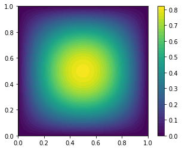

```
t = 0.02:
  u_r(0.5,0.5) = 0.66428
  u(0.5,0.5)   = 0.673825
```

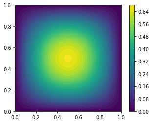

```
t = 0.03:
  u_r(0.5,0.5) = 0.544828
  u(0.5,0.5)   = 0.553122
```

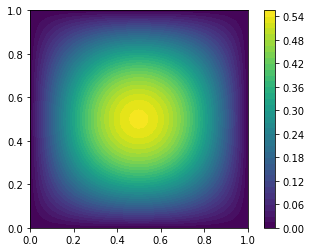

```
t = 0.04:
  u_r(0.5,0.5) = 0.446856
  u(0.5,0.5)   = 0.454041
```

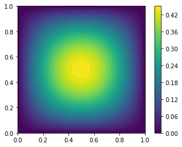

```
t = 0.05:
  u_r(0.5,0.5) = 0.366502
  u(0.5,0.5)   = 0.372708
```

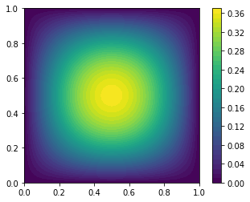

```
t = 0.06:
  u_r(0.5,0.5) = 0.300597
  u(0.5,0.5)   = 0.305944
```

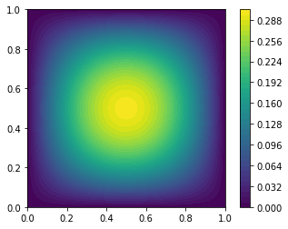

```
t = 0.07:
  u_r(0.5,0.5) = 0.246543
  u(0.5,0.5)   = 0.25114
```

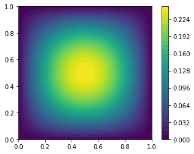

```
t = 0.08:
  u_r(0.5,0.5) = 0.202209
  u(0.5,0.5)   = 0.206153
```

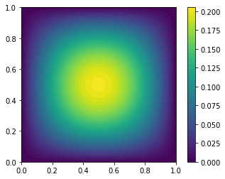

```
t = 0.09:
  u_r(0.5,0.5) = 0.165848
  u(0.5,0.5)   = 0.169225
```

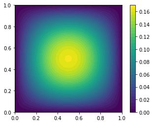

```
t = 0.1:
  u_r(0.5,0.5) = 0.136025
  u(0.5,0.5)   = 0.138911
```

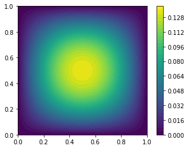

```
t = 0.11:
  u_r(0.5,0.5) = 0.111564
  u(0.5,0.5)   = 0.114028
```

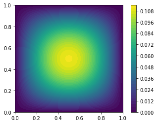

```
t = 0.12:
  u_r(0.5,0.5) = 0.091503
  u(0.5,0.5)   = 0.093602
```

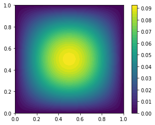

```
t = 0.13:
  u_r(0.5,0.5) = 0.075049
  u(0.5,0.5)   = 0.076835
```

[38 more figures not shown]

```python
# Time-stepping
n = 1
w = Function(V)

while(t+Δt <= T+1e-8):
    # Update current time
    t += Δt

    # Solve reduced linear system
    u_n = np.linalg.solve(reduced_system_matrix, np.dot(reduced_rhs_matrix, u_n))

    # Prolongate the reduced solution into the FOM space
    w.vector()[:] = np.dot(pod_basis, u_n)

    # Print results
    print(f"t = {round(t,4)}:")
    print(f"  u_r(0.5,0.5) = {round(w(Point(0.5, 0.5)),6)}")
    print(f"  u(0.5,0.5)   = {round(math.exp(-2 * math.pi**2 * t),6)}")

    # Plot solution
    c = plot(w)
    plt.colorbar(c)
    plt.show()

    # Store solution in snapshot matrix
    reduced_snapshots[:, n] = u_n
    n += 1
```

### Exercises

1. *Try out another model problem:* In this tutorial, we dealt with a heat equation with a uni-modal analytical solution and right hand side $f = 0$. Try a different problem, e.g. the heat equation from [step 26 of the deal.II tutorials](https://www.dealii.org/current/doxygen/deal.II/step_26.html#Thetestcase) with a time-dependent right hand side $f$. If you need a little help with this, please take a look at [Chapter 4 of my master's thesis](https://julianroth.org/res/Master_Thesis_Julian_Roth.pdf) which solves exactly this problem.

### Further resources on Reduced Order Modeling

- For a rigorous mathematical analysis of POD-ROM, please check out Volkwein's tutorials on this topic, e.g. [Chapter 2 from the book "Snapshot-Based Methods and Algorithms"](https://www.degruyter.com/document/doi/10.1515/9783110671490-002/html) or [his lecture notes](http://www.math.uni-konstanz.de/numerik/personen/volkwein/teaching/POD-Book.pdf) .
- For the application of ROMs to problems from fluid mechanics, I can recommend Chapter 9 on "Model Order Reduction in Fluid Dynamics: Challenges and Perspectives" from Quarteroni's and Rozza's book ["Reduced Order Methods for Modeling and Computation"](https://link.springer.com/chapter/10.1007/978-3-319-02090-7_9).
- Finally, feel free to take a closer look at [my master's thesis](https://julianroth.org/res/Master_Thesis_Julian_Roth.pdf), where I also demonstrate how proper orthogonal decomposition based reduced order models can be created for the heat equation and the laminar flow around a cylinder, which is a benchmark problem for the Navier-Stokes equations.